# ONS COVID Infection Survey - Example Solution

## ONS COVID Infection Survey Dataset

This data shows the daily COVID infection rate over a recent few weeks in each of none English Regions. The central estimate and 95% credible upper and lower bounds are given. This data is updated frequently on the [ONS website Coronavirus (COVID-19) Infection Survey page](https://www.ons.gov.uk/peoplepopulationandcommunity/healthandsocialcare/conditionsanddiseases/bulletins/coronaviruscovid19infectionsurveypilot/19february2021).

```r
covid_url <-
  "https://raw.githubusercontent.com/MarkWilcock/R-Course/main/Datasets/Covid%20Infection%20Survey.csv"
covid_df <- read_csv(covid_url)
head(covid_df)
```

| Date | North East-Central | North East-Lower | North East-Upper | North West-Central | North West-Lower | North West-Upper | Yorkshire and The Humber-Central | Yorkshire and The Humber-Lower | Yorkshire and The Humber-Upper | East Midlands-Central | East Midlands-Lower | East Midlands-Upper | West Midlands-Central | West Midlands-Lower | West Midlands-Upper | East of England-Central | East of England-Lower | East of England-Upper | London-Central | London-Lower | London-Upper | South East-Central | South East-Lower | South East-Upper | South West-Central | South West-Lower | South West-Upper |
| --- | --- | --- | --- | --- | --- | --- | --- | --- | --- | --- | --- | --- | --- | --- | --- | --- | --- | --- | --- | --- | --- | --- | --- | --- | --- | --- | --- |
| 2021-01-02 | 0.0230 | 0.0192 | 0.0270 | 0.0209 | 0.0187 | 0.0231 | 0.0136 | 0.0115 | 0.0158 | 0.0188 | 0.0161 | 0.0218 | 0.0189 | 0.0164 | 0.0216 | 0.0211 | 0.0188 | 0.0236 | 0.0333 | 0.0309 | 0.0356 | 0.0205 | 0.0185 | 0.0227 | 0.0094 | 0.0078 | 0.0111 |
| 2021-01-03 | 0.0239 | 0.0200 | 0.0281 | 0.0207 | 0.0185 | 0.0230 | 0.0134 | 0.0114 | 0.0157 | 0.0188 | 0.0160 | 0.0218 | 0.0190 | 0.0165 | 0.0219 | 0.0203 | 0.0180 | 0.0228 | 0.0326 | 0.0302 | 0.0350 | 0.0202 | 0.0181 | 0.0224 | 0.0098 | 0.0082 | 0.0117 |
| 2021-01-04 | 0.0246 | 0.0206 | 0.0291 | 0.0206 | 0.0184 | 0.0229 | 0.0132 | 0.0112 | 0.0155 | 0.0187 | 0.0158 | 0.0217 | 0.0191 | 0.0165 | 0.0220 | 0.0196 | 0.0173 | 0.0220 | 0.0321 | 0.0297 | 0.0344 | 0.0200 | 0.0179 | 0.0221 | 0.0103 | 0.0086 | 0.0122 |
| 2021-01-05 | 0.0252 | 0.0211 | 0.0297 | 0.0205 | 0.0184 | 0.0228 | 0.0130 | 0.0110 | 0.0152 | 0.0184 | 0.0156 | 0.0214 | 0.0192 | 0.0166 | 0.0221 | 0.0189 | 0.0167 | 0.0213 | 0.0316 | 0.0293 | 0.0339 | 0.0198 | 0.0178 | 0.0219 | 0.0109 | 0.0091 | 0.0128 |
| 2021-01-06 | 0.0255 | 0.0215 | 0.0301 | 0.0205 | 0.0184 | 0.0228 | 0.0127 | 0.0107 | 0.0149 | 0.0181 | 0.0154 | 0.0210 | 0.0192 | 0.0166 | 0.0220 | 0.0184 | 0.0163 | 0.0206 | 0.0313 | 0.0291 | 0.0335 | 0.0197 | 0.0178 | 0.0218 | 0.0114 | 0.0096 | 0.0134 |
| 2021-01-07 | 0.0256 | 0.0216 | 0.0301 | 0.0206 | 0.0186 | 0.0227 | 0.0124 | 0.0105 | 0.0145 | 0.0178 | 0.0151 | 0.0206 | 0.0191 | 0.0166 | 0.0219 | 0.0179 | 0.0160 | 0.0200 | 0.0310 | 0.0289 | 0.0331 | 0.0197 | 0.0178 | 0.0216 | 0.0120 | 0.0102 | 0.0140 |

Let’s reshape this dataset.

```r
covid_tidy <-
  covid_df %>%
  gather(key = "RegionMeasure", value = "Rate",-Date) %>%
  separate(RegionMeasure, c("Region", "Measure"), sep = "-")

covid_tidy
```

| Date | Region | Measure | Rate |
| --- | --- | --- | --- |
| 2021-01-02 | North East | Central | 0.0230 |
| 2021-01-03 | North East | Central | 0.0239 |
| 2021-01-04 | North East | Central | 0.0246 |
| 2021-01-05 | North East | Central | 0.0252 |
| 2021-01-06 | North East | Central | 0.0255 |
| 2021-01-07 | North East | Central | 0.0256 |
| 2021-01-08 | North East | Central | 0.0255 |
| 2021-01-09 | North East | Central | 0.0252 |
| 2021-01-10 | North East | Central | 0.0248 |
| 2021-01-11 | North East | Central | 0.0242 |

[output cut: 990 more lines]

*Exercise* Create a line chart to see how the COVID infection rate changes over time for each region

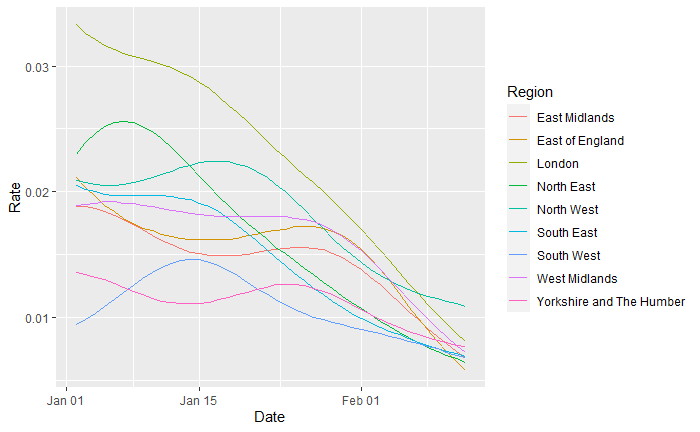

```r
covid_tidy_central <- covid_tidy %>% filter(Measure == "Central") %>% select(-Measure)

ggplot(covid_tidy_central,
       aes(x = Date, y = Rate, col = Region)) +
  geom_line()
```

*Exercise* Create a line chart that shows just the London Region - the value and the upper and lower bounds

We need these dataset for the next exercise

```r
covid_average_by_region <-
covid_tidy_central %>%
  group_by(Region) %>%
  summarise(AverageRate = mean(Rate))
```

*Exercise* Create a column chart that shows the average rate over the period by region

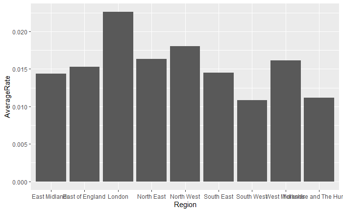

```r
ggplot(
covid_average_by_region,
aes(x=Region, y=AverageRate)) +
  geom_col()
```

*Exercise* - make this chart more appealing

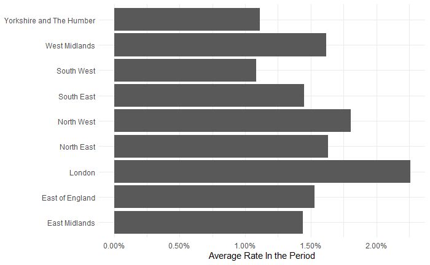

```r
library(scales) # required for the labels = percent
ggplot(covid_average_by_region,
       aes(x = Region, y = AverageRate)) +
  geom_col() +
  coord_flip() +
  theme_minimal() +
  scale_x_discrete(NULL) +
  scale_y_continuous("Average Rate In the Period", labels=percent)
```

*Exercise* Create a bar chart to show expected lifespan of women born in 2010 born by country.

## Scatter Plot (geom_point())

Scatter plots compare items across two continuous axes

# Small multiples

Let’s look at the infection rate in each region

```r
ggplot(covid_tidy_central,
       aes(x = Date, y = Rate)) +
  geom_line() +
  facet_wrap( ~ Region)
```

With small multiples we can put more details on to each chart e.g. the upper and lower bands as well as a central band

**Exercise**: Create a small multiple chart of each region where each chart shows the central, upper and lower bands

## Improve the look and effectiveness of our charts

```r
ggplot(covid_tidy_central,
       aes(x = Date, y = Rate, col = Region)) +
  geom_line() +
  ggtitle(
    "The percentage of people testing positive has decreased in all regions in the week ending 12 February 2021",
    "Estimated percentage of the population testing positive for the coronavirus (COVID-19) on nose and throat swabs, daily, by region since 2 January 2021, England")
```

labs() is possibly a better alternative since we can label title, axes and *captions* in one fell swoop.

```r
ggplot(covid_tidy_central,
       aes(x = Date, y = Rate, col = Region)) +
  geom_line() +
  labs(
    title = "COVID Rate decreased in all regions",
    subtitle  = "Percentage of the population testing positive",
    caption = "Source: https://www.ons.gov.uk/peoplepopulationandcommunity/"
  )
```

```r
ggplot(covid_tidy_central,
       aes(x = Date, y = Rate, col = Region)) +
  geom_line() +
  ggtitle(
    "COVID Rate decreased in all regions",
    "Percentage of the population testing positive") +
  xlab("Date (Daily Measurements") +
  ylab("Estimated Infection Rate")
```

```r
ggplot(covid_tidy_central,
       aes(x = Date, y = Rate, col = Region)) +
  geom_line() +
  #theme(legend.position = "bottom") +
  scale_color_discrete (guide = guide_legend(title = "English Region"))
```

*Exercise* Move the legend to the bottom of the chart

```r
ggplot(covid_tidy_central,
       aes(x = Date, y = Rate, col = Region)) +
  geom_line() +
  scale_x_date ("Date Axis", date_labels = "%b %y") +
  scale_y_continuous("Infection Rate", limits = c(0, 0.04), labels = scales::percent)
```

## Reference Lines, Annotations and Labels

```r
(covid_tidy_central_london <-
  covid_tidy_central %>% filter(Region == "London") %>%
  select(-Region)
)
```

```r
ggplot(covid_tidy_central_london    ,
       aes(x = Date, y = Rate)) +
  geom_line() +
  geom_hline(yintercept = 0.02, col="red", linetype="dashed") +
  annotate("text", x = min(covid_tidy_central_london$Date), y = 0.02, label = "Lockdown Level", vjust = -0.5, hjust = 0)
```

Try out different themes. Use the auto-complete and documentation to see the themes available. Which do you prefer?

```r
ggplot(covid_tidy_central,
       aes(x = Date, y = Rate, col = Region)) +
  geom_line() +
  ggtitle(
    "COVID Rate decreased in all regions",
    "Percentage of the population testing positive") +
  xlab("Date (Daily Measurements") +
  ylab("Estimated Infection Rate") +
  theme_light()
```

```r
ggplot(covid_tidy_central,
       aes(x = Date, y = Rate, col = Region)) +
  geom_line() +
  ggtitle(
    "COVID Rate decreased in all regions",
    "Percentage of the population testing positive") +
  xlab("Date (Daily Measurements") +
  ylab("Estimated Infection Rate") +
  theme_light() +
  theme(plot.background = element_rect(fill="yellow"))
```

*Exercise* Build a chart with a minimal themes apart from a green panel background

```r
ggplot(covid_tidy_central,
       aes(x = Date, y = Rate, col = Region)) +
  geom_line() +
  ggtitle(
    "COVID Rate decreased in all regions",
    "Percentage of the population testing positive") +
  xlab("Date (Daily Measurements") +
  ylab("Estimated Infection Rate") +
  theme_economist()
```

**Exercise**: Create a small multiple chart of each region where each chart shows the central, upper and lower bands

```r
#  Exercise answer
ggplot(covid_tidy,
       aes(x = Date, y = Rate, col = Measure)) +
  geom_line() +
  facet_wrap( ~ Region)
```